# Analysis of Annual Stack Overflow Survey 2019

- In this notebook I analyze the Annual Stack Overflow Survey 2019
- Full dataset is publicly available for downloaded at https://insights.stackoverflow.com/survey
- Data used for analysis below can be downloaded via **Download Full Data Set (CSV)** (2019)
- Since data set is to large to be included in this repository, please download and import the file in case you want to reproduce the analysis

## Data Exploration

```python
# Imports

import pandas as pd
import numpy as np
import html.parser
import os
import sys
from IPython.core.display import HTML
from IPython.core.interactiveshell import InteractiveShell
InteractiveShell.ast_node_interactivity = "all"
import matplotlib.pyplot as plt
import seaborn as sns
```

```python
#Setting pandas display options

pd.set_option("display.max_rows",152)
pd.set_option("display.max_columns",None)
pd.set_option("display.max_colwidth", -1)
pd.set_option("display.width",None)
```

```python
os.listdir()
os.getcwd()
```

```
['.ipynb_checkpoints',
 'Blog_Post',
 'Blog_Post1.ipynb',
 'Data1_SO2017',
 'Data2_AllYears',
 'Images',
 'Stack_Overflow_Survey_Data_Preparation.ipynb',
 'test.png',
 'Untitled.ipynb',
 'Untitled1.ipynb']
```

```
'C:\\Users\\migue\\Dropbox\\Sonstiges\\Weiterbildung\\Data Scientist\\Term2\\Blog_Post'
```

## Understanding the Data Set

### Loading Provided Survey Schema

```python
# Analyzing the schema to get a general idea of the data set

schema_data = pd.read_csv(".\\Data2_AllYears\\developer_survey_2019\\survey_results_schema.csv")

schema_data
```

|  | Column | QuestionText |
| --- | --- | --- |
| 0 | Respondent | Randomized respondent ID number (not in order of survey response time) |
| 1 | MainBranch | Which of the following options best describes you today? Here, by "developer" we mean "someone who writes code." |
| 2 | Hobbyist | Do you code as a hobby? |
| 3 | OpenSourcer | How often do you contribute to open source? |
| 4 | OpenSource | How do you feel about the quality of open source software (OSS)? |
| 5 | Employment | Which of the following best describes your current employment status? |
| 6 | Country | In which country do you currently reside? |
| 7 | Student | Are you currently enrolled in a formal, degree-granting college or university program? |
| 8 | EdLevel | Which of the following best describes the highest level of formal education that you’ve completed? |
| 9 | UndergradMajor | What was your main or most important field of study? |
| 10 | EduOther | Which of the following types of non-degree education have you used or participated in? Please select all that apply. |
| 11 | OrgSize | Approximately how many people are employed by the company or organization you work for? |
| 12 | DevType | Which of the following describe you? Please select all that apply. |
| 13 | YearsCode | Including any education, how many years have you been coding? |
| 14 | Age1stCode | At what age did you write your first line of code or program? (E.g., webpage, Hello World, Scratch project) |
| 15 | YearsCodePro | How many years have you coded professionally (as a part of your work)? |
| 16 | CareerSat | Overall, how satisfied are you with your career thus far? |
| 17 | JobSat | How satisfied are you with your current job? (If you work multiple jobs, answer for the one you spend the most hours on.) |
| 18 | MgrIdiot | How confident are you that your manager knows what they’re doing? |
| 19 | MgrMoney | Do you believe that you need to be a manager to make more money? |
| 20 | MgrWant | Do you want to become a manager yourself in the future? |
| 21 | JobSeek | Which of the following best describes your current job-seeking status? |
| 22 | LastHireDate | When was the last time that you took a job with a new employer? |
| 23 | LastInt | In your most recent successful job interview (resulting in a job offer), you were asked to... (check all that apply) |
| 24 | FizzBuzz | Have you ever been asked to solve FizzBuzz in an interview? |
| 25 | JobFactors | Imagine that you are deciding between two job offers with the same compensation, benefits, and location. Of the following factors, which 3 are MOST important to you? |
| 26 | ResumeUpdate | Think back to the last time you updated your resumé, CV, or an online profile on a job site. What is the PRIMARY reason that you did so? |
| 27 | CurrencySymbol | Which currency do you use day-to-day? If your answer is complicated, please pick the one you're most comfortable estimating in. |
| 28 | CurrencyDesc | Which currency do you use day-to-day? If your answer is complicated, please pick the one you're most comfortable estimating in. |
| 29 | CompTotal | What is your current total compensation (salary, bonuses, and perks, before taxes and deductions), in `CurrencySymbol`? Please enter a whole number in the box below, without any punctuation. If you ar… |

[output cut: 55 more lines]

```python
schema_data.shape
```

```
(85, 2)
```

```python
schema_data.info()
```

```
<class 'pandas.core.frame.DataFrame'>
RangeIndex: 85 entries, 0 to 84
Data columns (total 2 columns):
Column          85 non-null object
QuestionText    85 non-null object
dtypes: object(2)
memory usage: 1.4+ KB
```

## Defining analysis scope based on survey schema

- Based on the survey schema I want to run an in-depth analysis on the topics block "Questions 43-52"
- These questions all follow the following schema:

"Which of the following [...] have you done extensive development work in over the past year, and which do you want to work in over the next year? (If you both worked with the language and want to continue to do so, please check both boxes in that row.)"

#### Question was asked for

- programming,scripting markup languages
- database environments
- platforms
- web frameworks
- miscellaneous technologies

I want to analyze, whether some trends can be discovered in the data, regarding popularity of these elements.

### Loading Survey Data

```python
# Loading Data

data = pd.read_csv(".\\Data2_AllYears\\developer_survey_2019\\survey_results_public.csv")
```

```python
data.info()
```

```
<class 'pandas.core.frame.DataFrame'>
RangeIndex: 88883 entries, 0 to 88882
Data columns (total 85 columns):
Respondent                88883 non-null int64
MainBranch                88331 non-null object
Hobbyist                  88883 non-null object
OpenSourcer               88883 non-null object
OpenSource                86842 non-null object
Employment                87181 non-null object
Country                   88751 non-null object
Student                   87014 non-null object
EdLevel                   86390 non-null object
UndergradMajor            75614 non-null object
EduOther                  84260 non-null object
OrgSize                   71791 non-null object
DevType                   81335 non-null object
YearsCode                 87938 non-null object
Age1stCode                87634 non-null object
YearsCodePro              74331 non-null object
CareerSat                 72847 non-null object
JobSat                    70988 non-null object
MgrIdiot                  61159 non-null object
MgrMoney                  61157 non-null object
MgrWant                   61232 non-null object
JobSeek                   80555 non-null object
LastHireDate              79854 non-null object
LastInt                   67155 non-null object
FizzBuzz                  71344 non-null object
JobFactors                79371 non-null object
ResumeUpdate              77877 non-null object
CurrencySymbol            71392 non-null object
CurrencyDesc              71392 non-null object
CompTotal                 55945 non-null float64
CompFreq                  63268 non-null object
ConvertedComp             55823 non-null float64
WorkWeekHrs               64503 non-null float64
WorkPlan                  68914 non-null object
WorkChallenge             68141 non-null object
WorkRemote                70284 non-null object
WorkLoc                   70055 non-null object
```

[output cut: 35 more lines]

```
SOJobs                    88066 non-null object
EntTeams                  87841 non-null object
SOComm                    88131 non-null object
WelcomeChange             85855 non-null object
SONewContent              69560 non-null object
Age                       79210 non-null float64
Gender                    85406 non-null object
Trans                     83607 non-null object
Sexuality                 76147 non-null object
Ethnicity                 76668 non-null object
Dependents                83059 non-null object
SurveyLength              86984 non-null object
SurveyEase                87081 non-null object
dtypes: float64(5), int64(1), object(79)
memory usage: 57.6+ MB
```

```python
# Generatingnew dataframe as subset of the survey only containing the relevant questions (43-52)

have_want_work = data.loc[:,"LanguageWorkedWith":"MiscTechDesireNextYear"]

have_want_work.info()
```

```
<class 'pandas.core.frame.DataFrame'>
RangeIndex: 88883 entries, 0 to 88882
Data columns (total 10 columns):
LanguageWorkedWith        87569 non-null object
LanguageDesireNextYear    84088 non-null object
DatabaseWorkedWith        76026 non-null object
DatabaseDesireNextYear    69147 non-null object
PlatformWorkedWith        80714 non-null object
PlatformDesireNextYear    77443 non-null object
WebFrameWorkedWith        65022 non-null object
WebFrameDesireNextYear    62944 non-null object
MiscTechWorkedWith        59586 non-null object
MiscTechDesireNextYear    64511 non-null object
dtypes: object(10)
memory usage: 6.8+ MB
```

```python
have_want_work.head()
```

|  | LanguageWorkedWith | LanguageDesireNextYear | DatabaseWorkedWith | DatabaseDesireNextYear | PlatformWorkedWith | PlatformDesireNextYear | WebFrameWorkedWith | WebFrameDesireNextYear | MiscTechWorkedWith | MiscTechDesireNextYear |
| --- | --- | --- | --- | --- | --- | --- | --- | --- | --- | --- |
| 0 | HTML/CSS;Java;JavaScript;Python | C;C++;C#;Go;HTML/CSS;Java;JavaScript;Python;SQL | SQLite | MySQL | MacOS;Windows | Android;Arduino;Windows | Django;Flask | Flask;jQuery | Node.js | Node.js |
| 1 | C++;HTML/CSS;Python | C++;HTML/CSS;JavaScript;SQL | NaN | MySQL | Windows | Windows | Django | Django | NaN | NaN |
| 2 | HTML/CSS | Elixir;HTML/CSS | PostgreSQL | PostgreSQL | NaN | NaN | NaN | Other(s): | NaN | NaN |
| 3 | C;C++;C#;Python;SQL | C;C#;JavaScript;SQL | MySQL;SQLite | MySQL;SQLite | Linux;Windows | Linux;Windows | NaN | NaN | .NET | .NET |
| 4 | C++;HTML/CSS;Java;JavaScript;Python;SQL;VBA | HTML/CSS;Java;JavaScript;SQL;WebAssembly | Couchbase;MongoDB;MySQL;Oracle;PostgreSQL;SQLite | Couchbase;Firebase;MongoDB;MySQL;Oracle;PostgreSQL;SQLite | Android;Linux;MacOS;Slack;Windows | Android;Docker;Kubernetes;Linux;Slack | Django;Express;Flask;jQuery;React.js;Spring | Flask;jQuery;React.js;Spring | Cordova;Node.js | Apache Spark;Hadoop;Node.js;React Native |

### Handling missing data

Many respondents haven't answered this question block or only partially answered the question block. Since I want to run a comparison on the years 2019 and 2020 I will only consider survey participants that answered the complete question block and remove respondents with missing values from the dataset

```python
# Removing all respondents that haven't entirely answered the question block from the dataset

have_want_work = have_want_work[~have_want_work.isnull().any(axis=1)]
```

```python
# Checking if respondents have been entirely removed from data set.
```

```python
have_want_work.info()
```

```
<class 'pandas.core.frame.DataFrame'>
Int64Index: 34181 entries, 0 to 88878
Data columns (total 10 columns):
LanguageWorkedWith        34181 non-null object
LanguageDesireNextYear    34181 non-null object
DatabaseWorkedWith        34181 non-null object
DatabaseDesireNextYear    34181 non-null object
PlatformWorkedWith        34181 non-null object
PlatformDesireNextYear    34181 non-null object
WebFrameWorkedWith        34181 non-null object
WebFrameDesireNextYear    34181 non-null object
MiscTechWorkedWith        34181 non-null object
MiscTechDesireNextYear    34181 non-null object
dtypes: object(10)
memory usage: 2.9+ MB
```

```python
have_want_work.head()
```

|  | LanguageWorkedWith | LanguageDesireNextYear | DatabaseWorkedWith | DatabaseDesireNextYear | PlatformWorkedWith | PlatformDesireNextYear | WebFrameWorkedWith | WebFrameDesireNextYear | MiscTechWorkedWith | MiscTechDesireNextYear |
| --- | --- | --- | --- | --- | --- | --- | --- | --- | --- | --- |
| 0 | HTML/CSS;Java;JavaScript;Python | C;C++;C#;Go;HTML/CSS;Java;JavaScript;Python;SQL | SQLite | MySQL | MacOS;Windows | Android;Arduino;Windows | Django;Flask | Flask;jQuery | Node.js | Node.js |
| 4 | C++;HTML/CSS;Java;JavaScript;Python;SQL;VBA | HTML/CSS;Java;JavaScript;SQL;WebAssembly | Couchbase;MongoDB;MySQL;Oracle;PostgreSQL;SQLite | Couchbase;Firebase;MongoDB;MySQL;Oracle;PostgreSQL;SQLite | Android;Linux;MacOS;Slack;Windows | Android;Docker;Kubernetes;Linux;Slack | Django;Express;Flask;jQuery;React.js;Spring | Flask;jQuery;React.js;Spring | Cordova;Node.js | Apache Spark;Hadoop;Node.js;React Native |
| 7 | Bash/Shell/PowerShell;C;C++;HTML/CSS;Java;JavaScript;Python;SQL | Bash/Shell/PowerShell;C;C++;Elixir;Erlang;Go;Python;SQL;WebAssembly | Cassandra;Elasticsearch;MongoDB;MySQL;Oracle;Redis;SQLite | Cassandra;DynamoDB;Elasticsearch;Firebase;MongoDB;MySQL;PostgreSQL;Redis | AWS;Docker;Heroku;Linux;MacOS;Slack | Android;Arduino;AWS;Docker;Google Cloud Platform;IBM Cloud or Watson;Kubernetes;Linux;MacOS;Raspberry Pi;Slack | Express;Flask;React.js;Spring | Django;Express;Flask;React.js;Vue.js | Hadoop;Node.js;Pandas | Ansible;Apache Spark;Chef;Hadoop;Node.js;Pandas;Puppet;React Native;TensorFlow;Torch/PyTorch;Unreal Engine |
| 8 | Bash/Shell/PowerShell;C#;HTML/CSS;JavaScript;Python;Ruby;Rust;SQL;TypeScript;WebAssembly;Other(s): | Bash/Shell/PowerShell;C;HTML/CSS;JavaScript;Ruby;Rust;SQL;TypeScript;WebAssembly;Other(s): | DynamoDB;PostgreSQL;SQLite | PostgreSQL;Redis;SQLite | AWS;Docker;Heroku;Linux;MacOS;Slack | AWS;Docker;Heroku;Linux;MacOS;Slack;Other(s): | Express;Ruby on Rails;Other(s): | Express;Ruby on Rails;Other(s): | Node.js;Unity 3D | Node.js |
| 9 | C#;Go;JavaScript;Python;R;SQL | C#;Go;JavaScript;Kotlin;Python;R;SQL | Elasticsearch;MongoDB;Microsoft SQL Server;MySQL;SQLite | Elasticsearch;MongoDB;Microsoft SQL Server | Linux;Windows | Android;Linux;Raspberry Pi;Windows | Angular/Angular.js;ASP.NET;Django;Express;Flask;jQuery | Angular/Angular.js;ASP.NET;Django;Express;Flask;jQuery | .NET;Node.js;Pandas;Torch/PyTorch | .NET;Node.js;TensorFlow;Torch/PyTorch |

## Preparing the Data

- The relevant columns in the data set each contain multiple elements in a single cell separated by a semicolon.
- e.g. programming languages = Ruby; Java; Python
- Also sometimes there is a trailing white space contained before or after the semi colon.
- For further analysis I will generate a function to split the data and remove trailing white spaces

```python
def generate_columns_set(have,want):
    """Takes in columns belonging to relevant questions block (43-52). Splits and cleans the data.
    Generates set of all unique elements. This set can be used to setup a unique column by element (e.g. have used
    language = python) in analyzing_have_want method below

    Args:
        have (pandas series): Contains all elements currently in use by the respondent for a topic (e.g. all languages used)
        want (pandas series): Contains all elements the respondent wants to use in 2020 for a topic (e.g. all languages used)

    Returns:
        Set of all elements the respondent either is currently using or wants to use in the future
    """

    overview_set = set()
    for element_have, element_want in zip(have,want):
        # Adding all elements to overview set
        overview_set = overview_set | set(element_have.split(";")) | set(element_want.split(";"))
        # Cleaning overview set, since it contains white spaces before or after some of the strings
        overview_set = set([x.strip() for x in list(overview_set)])
    return overview_set
```

```python
"""
Using generate_columns_set function to generate a unique columns set.
Columns set contains all unique elements, e.g. all unique languages that have been used by the respondents in the dataset
"""

columns_set_languages = generate_columns_set(have_want_work["LanguageWorkedWith"],have_want_work["LanguageDesireNextYear"])
columns_set_databases = generate_columns_set(have_want_work["DatabaseWorkedWith"],have_want_work["DatabaseDesireNextYear"])
columns_set_platforms = generate_columns_set(have_want_work["PlatformWorkedWith"],have_want_work["PlatformDesireNextYear"])
columns_set_webframes = generate_columns_set(have_want_work["WebFrameWorkedWith"],have_want_work["WebFrameDesireNextYear"])
columns_set_misctechs = generate_columns_set(have_want_work["MiscTechWorkedWith"],have_want_work["MiscTechDesireNextYear"])
```

```
'\nUsing generate_columns_set function to generate a unique columns set.\nColumns set contains all unique elements, e.g. all unique languages that have been used by the respondents in the dataset\n'
```

## Modelling the Data

- Now that I have all unique elements for all categories, I can use this information to **set up an item interaction matrix by category**.
- The matrix will **contain a column for each unique element**, e.g. each unique language used by respondents in the data set.
- The **respondents will make up the rows** of the matrix
- In case a respondent **has / wants to use one** of the elements the matrix entry will be set to **1** for the respective column.
- If the respondent **hasn't/doesn't want to** interacted with the element, the matrix will contain a **0** for this element.

```python
def analyze_have_want(questionnaire_column,columns_set):
    """Takes in columns belonging to relevant questions block (43-52). Splits and cleans the data. The aim is to generate
    an item interaction matrix, showing 1 if a user has/wants to interact with an item and 0 if not.

    Args:
        questionnaire_column (pandas series) = Column with user responses for relevant question, e.g. "LanguageWorkedWith"
        columns_set (set) = Set of all unique elements in a category, e.g. all languages

    Returns:
            Item interaction Dataframe, showing 1 if a user has/wants to interact with a certain
            tool/framework/language etc. and 0 if not.

    """

    # Setting up empty dataframe containing all unique elements by category as columns
    item_interaction = pd.DataFrame(columns = columns_set)

    # Adding column containing user response for relevant question e.g. "LanguageWorkedWith" to dataframe

    item_interaction[questionnaire_column] = have_want_work[questionnaire_column]

    # First filling all columns with 0's

    item_interaction.fillna(0, inplace = True)

    # Iterating over all element combinations and getting corresponding row_index of user in dataframe.
    for row_index, questionnaire_response in item_interaction[questionnaire_column].items():
        responses = questionnaire_response.split(";") if len(questionnaire_response.split(";")) > 0 else list()
        # Cleaning elements list, since somteimes whitespaces are used before or after words
        responses = [x.strip() for x in responses]

        # Checking unique elements in questionnaire response and setting related column in item_interaction df to 1
        for element in responses:

            # Iterating over all columns in column_set. Checking if given current element matches column.
            for column_name in columns_set:
                if element == column_name:
                    item_interaction.at[row_index, column_name] = 1

    return item_interaction
```

```python
# Creating all relevant Item Interaction Dataframes per category

df_have_worked_languages = analyze_have_want("LanguageWorkedWith",columns_set_languages)
df_want_work_languages = analyze_have_want("LanguageDesireNextYear",columns_set_languages)
df_have_worked_databases = analyze_have_want("DatabaseWorkedWith",columns_set_databases)
df_want_work_databases = analyze_have_want("DatabaseDesireNextYear",columns_set_databases)
df_have_worked_platforms = analyze_have_want("PlatformWorkedWith",columns_set_platforms)
df_want_work_platforms = analyze_have_want("PlatformDesireNextYear",columns_set_platforms)
df_have_worked_webframes = analyze_have_want("WebFrameWorkedWith",columns_set_webframes)
df_want_work_webframes = analyze_have_want("WebFrameDesireNextYear",columns_set_webframes)
df_have_worked_misctechs = analyze_have_want("MiscTechWorkedWith",columns_set_misctechs)
df_want_work_misctechs = analyze_have_want("MiscTechDesireNextYear",columns_set_misctechs)
```

```python
# Checking if item interaction dataframes have been set up correctly

df_have_worked_languages.head()
```

|  | Objective-C | C | VBA | Python | Java | R | Assembly | Swift | HTML/CSS | F# | C# | WebAssembly | Erlang | Other(s): | Bash/Shell/PowerShell | C++ | Ruby | Clojure | JavaScript | Scala | Dart | TypeScript | Kotlin | SQL | PHP | Go | Rust | Elixir | LanguageWorkedWith |
| --- | --- | --- | --- | --- | --- | --- | --- | --- | --- | --- | --- | --- | --- | --- | --- | --- | --- | --- | --- | --- | --- | --- | --- | --- | --- | --- | --- | --- | --- |
| 0 | 0 | 0 | 0 | 1 | 1 | 0 | 0 | 0 | 1 | 0 | 0 | 0 | 0 | 0 | 0 | 0 | 0 | 0 | 1 | 0 | 0 | 0 | 0 | 0 | 0 | 0 | 0 | 0 | HTML/CSS;Java;JavaScript;Python |
| 4 | 0 | 0 | 1 | 1 | 1 | 0 | 0 | 0 | 1 | 0 | 0 | 0 | 0 | 0 | 0 | 1 | 0 | 0 | 1 | 0 | 0 | 0 | 0 | 1 | 0 | 0 | 0 | 0 | C++;HTML/CSS;Java;JavaScript;Python;SQL;VBA |
| 7 | 0 | 1 | 0 | 1 | 1 | 0 | 0 | 0 | 1 | 0 | 0 | 0 | 0 | 0 | 1 | 1 | 0 | 0 | 1 | 0 | 0 | 0 | 0 | 1 | 0 | 0 | 0 | 0 | Bash/Shell/PowerShell;C;C++;HTML/CSS;Java;JavaScript;Python;SQL |
| 8 | 0 | 0 | 0 | 1 | 0 | 0 | 0 | 0 | 1 | 0 | 1 | 1 | 0 | 1 | 1 | 0 | 1 | 0 | 1 | 0 | 0 | 1 | 0 | 1 | 0 | 0 | 1 | 0 | Bash/Shell/PowerShell;C#;HTML/CSS;JavaScript;Python;Ruby;Rust;SQL;TypeScript;WebAssembly;Other(s): |
| 9 | 0 | 0 | 0 | 1 | 0 | 1 | 0 | 0 | 0 | 0 | 1 | 0 | 0 | 0 | 0 | 0 | 0 | 0 | 1 | 0 | 0 | 0 | 0 | 1 | 0 | 1 | 0 | 0 | C#;Go;JavaScript;Python;R;SQL |

## Visualizing The Data

- Now that all relevant item interaction dataframes have been created looking for a way to sort and visualize the data.

```python
def visualize_have_want(questionnaire_column,analyzed_have_want):
    """Takes in a questionnaire_column belonging to relevant questions block (43-52) and an item_interaction dataframe.
    Sums up and sorts the usage and visualizes it in form of a horizontal barchart.

    Args:
        questionnaire_column (str): Name of relevant questionnaire column, e.g. "LanguageWorkedWith"
        analyzed_have_want (panadas dataframe): Item interaction matrix showing 1 for interaction and 0 for none interaction
    """

    # https://stackoverflow.com/questions/29763620/how-to-select-all-columns-except-one-column-in-pandas
    # Calculating the sum of item usage along the column. Removing the column containing the non-split data from dataframe
    ranked_items = analyzed_have_want.loc[:, analyzed_have_want.columns != questionnaire_column].sum(axis = 0)

    # Sorting the results values
    ranked_items = ranked_items.sort_values()

    # Plotting data
    plt.rcParams["figure.figsize"] = (8,8)
    plt.barh(ranked_items.index,ranked_items.values)
    plt.show;
```

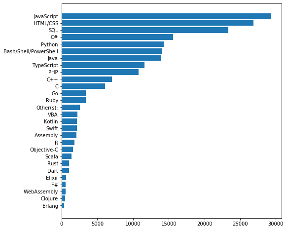

```python
visualize_have_want("LanguageWorkedWith",df_have_worked_languages)
```

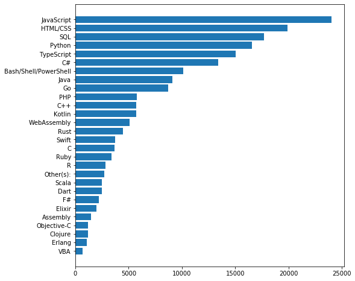

```python
visualize_have_want("LanguageDesireNextYear",df_want_work_languages)
```

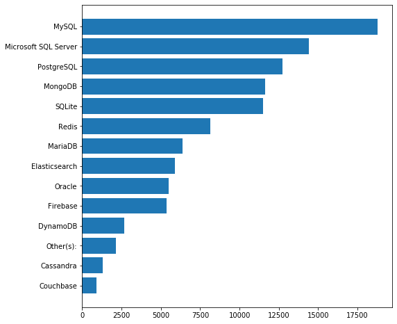

```python
visualize_have_want("DatabaseWorkedWith",df_have_worked_databases)
```

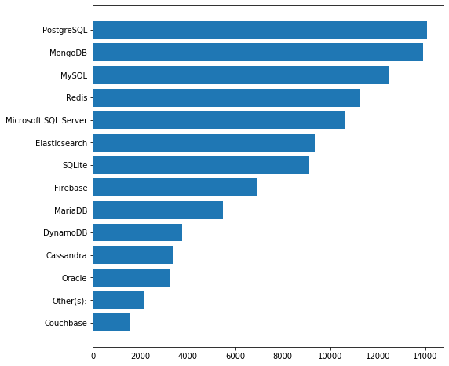

```python
visualize_have_want("DatabaseDesireNextYear",df_want_work_databases)
```

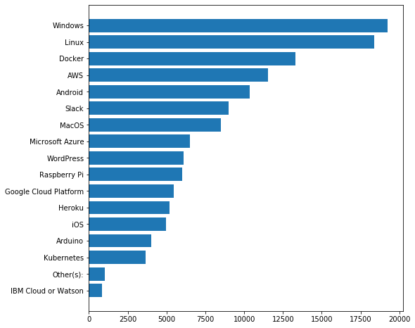

```python
visualize_have_want("PlatformWorkedWith",df_have_worked_platforms)
```

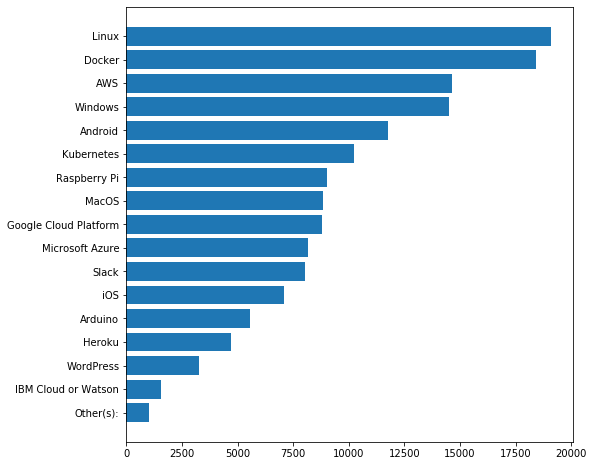

```python
visualize_have_want("PlatformDesireNextYear",df_want_work_platforms)
```

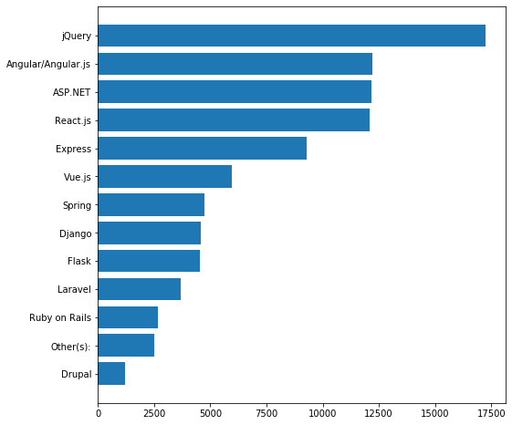

```python
visualize_have_want("WebFrameWorkedWith",df_have_worked_webframes)
```

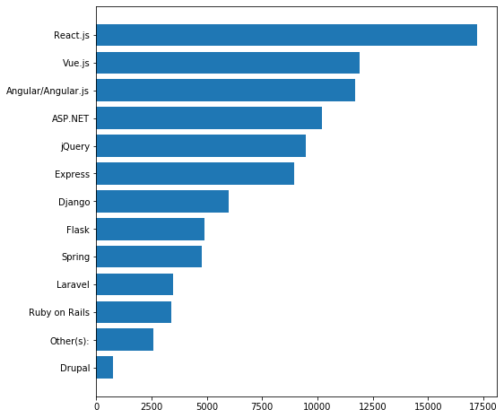

```python
visualize_have_want("WebFrameDesireNextYear",df_want_work_webframes)
```

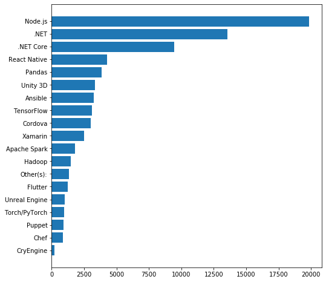

```python
visualize_have_want("MiscTechWorkedWith",df_have_worked_misctechs)
```

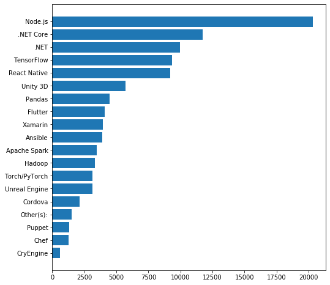

```python
visualize_have_want("MiscTechDesireNextYear",df_want_work_misctechs)
```

## Finding matches in current and desired tech usage

- After reviewing the above graphs it seems that there is a great difference between current and expected, desired usage next year
- For the blog post, I want to analyze the percentage of users that intend to use the exact same elements by category in 2020 based on their usagein 2019.

```python
"""
Comparing Current Situation 2019 and Desired Situation in 2020

Generating interim dataframe to identify similar usage
(Don't want to alter the original dataframe for this separate analysis)
"""

finding_matches = have_want_work.copy()

def find_matches(have,want,finding_matches=finding_matches):
    """Conducts a pairwise comparison of all elements in provided two pandas series.

    Args:
        have (pandas series): Contains all elements currently in use by the respondent for a topic (e.g. all languages used)
        want (pandas series): Contains all elements the respondent wants to use in 2020 for a topic (e.g. all languages used)
        finding_matches (pandas dataframe): Contains a copy of the to be analyzed dataframe
    Returns:
        Sum of all exact (non-)matches of the pairwise comparison
    """

    # Generating lookup column which will display whether or not the pairwise comparison is an exact match
    finding_matches["Matching_Result"] = np.where(
        finding_matches[have].apply(
        lambda x : set(element.strip() for element in x.split(";")) if len(x) >= 1 else "Not Matching") ==
        finding_matches[want].apply(
        lambda x : set(element.strip() for element in x.split(";")) if len(x) >= 1 else "Not Matching")
        , "Matching","Not Matching")

    return finding_matches["Matching_Result"].value_counts()
```

```
"\nComparing Current Situation 2019 and Desired Situation in 2020\n\nGenerating interim dataframe to identify similar usage \n(Don't want to alter the original dataframe for this separate analysis)\n"
```

```python
def visualize_matches(matches_count):
    """
    Plots the result of find_matches function above

    Args:
        matches_count (pandas series): Contains result of find_matches function
    """
    print(type(matches_count))
    matches_count = pd.DataFrame(matches_count)
    print(matches_count)
    plt.rcParams["figure.figsize"] = (5,5)
    matches_count.plot.bar(stacked = True);
```

```python
# List containing all relevant columns to be visualized

relevant_columns = have_want_work.columns.tolist()
print(relevant_columns)

# Generating dataframe dedicated to visualization purpose
matches_counts = pd.DataFrame()

# Iterating over all relevant column combinations, e.g. 'LanguageWorkedWith' <> 'LanguageDesireNextYear'
for element in range(0,9)[::2]:
    print("\nComparing {} <> {}".format(relevant_columns[element],relevant_columns[element+1]))
    # Adding result of find_matches to matches_count dataframe
    matches_count = find_matches(relevant_columns[element],relevant_columns[element+1])
    print(matches_count)
    #visualize_matches(matches_count);
    matches_counts = pd.concat([matches_counts,matches_count], axis=1,sort=False)
```

```
['LanguageWorkedWith', 'LanguageDesireNextYear', 'DatabaseWorkedWith', 'DatabaseDesireNextYear', 'PlatformWorkedWith', 'PlatformDesireNextYear', 'WebFrameWorkedWith', 'WebFrameDesireNextYear', 'MiscTechWorkedWith', 'MiscTechDesireNextYear']

Comparing LanguageWorkedWith <> LanguageDesireNextYear
Not Matching    30022
Matching        4159
Name: Matching_Result, dtype: int64

Comparing DatabaseWorkedWith <> DatabaseDesireNextYear
Not Matching    25673
Matching        8508
Name: Matching_Result, dtype: int64

Comparing PlatformWorkedWith <> PlatformDesireNextYear
Not Matching    26705
Matching        7476
Name: Matching_Result, dtype: int64

Comparing WebFrameWorkedWith <> WebFrameDesireNextYear
Not Matching    24867
Matching        9314
Name: Matching_Result, dtype: int64

Comparing MiscTechWorkedWith <> MiscTechDesireNextYear
Not Matching    24725
Matching        9456
Name: Matching_Result, dtype: int64
```

## Visualizing matches in current and desired tech usage

```
Index(['Languages', 'Databases', 'Platforms', 'Webframes', 'MiscTech'], dtype='object')
```

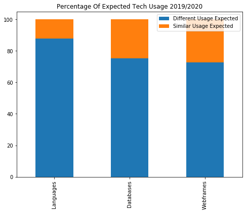

```python
# Formatting matches_counts df to generate visualization as stacked barchart.

%matplotlib inline

# Inputing column names
matches_counts.columns = ["Languages","Databases","Platforms","Webframes","MiscTech"]

# Transposing Dataframe
matches_counts = matches_counts.transpose()

# Calculating relative values to display values as percentage in stacked bar chart
matches_counts["Matching"] = (matches_counts["Matching"] / have_want_work.shape[0]) * 100
matches_counts["Not Matching"] = (matches_counts["Not Matching"] / have_want_work.shape[0]) * 100

# Changing Column Names for display in graph
matches_counts.columns = ["Different Usage Expected","Similar Usage Expected"]

# Generating Subset of Dataframe so that graph only shows items relevant for the blog post
print(matches_counts.index)

matches_counts = matches_counts.loc[["Languages","Databases","Webframes"]]

# Setting size of graph
plt.rcParams["figure.figsize"] = (8,6)

# Plotting as stacked barchart
matches_counts.plot.bar(stacked=True,title="Percentage Of Expected Tech Usage 2019/2020")
```

### Visualizing pairwise comparisons current and desired situation for blog post

- The above visuals are already quite insightful, but want to visualize it better and more compact for the blog post
- Therefore want to show pairwise comparisons in one graph as opposed to separate graphs

```python
# Get ranked data

def get_ranked_data(questionnaire_column,analyzed_have_want):
    """
    Takes in name of relevant questionnaire column and item interaction matrix. Aim is to return a list of ranked items

    Args:
        questionnaire_column (str): Name of relevant questionnaire column, e.g. "LanguageWorkedWith"
        analyzed_have_want (panadas dataframe): Item interaction matrix showing 1 for interaction and 0 for none interaction

    Returns:
        Ranked List of items including their counts
    """
    # https://stackoverflow.com/questions/29763620/how-to-select-all-columns-except-one-column-in-pandas
    ranked_items = analyzed_have_want.loc[:, analyzed_have_want.columns != questionnaire_column].sum(axis = 0)
    ranked_items = ranked_items.sort_values()
    return ranked_items

# Testing output of get_ranked_data
databases_worked_ranked = get_ranked_data("DatabaseWorkedWith",df_have_worked_databases)
print(databases_worked_ranked)
databases_desire_ranked = get_ranked_data("DatabaseDesireNextYear",df_want_work_databases)
print(databases_worked_ranked)
```

```
Couchbase               904
Cassandra               1295
Other(s):               2154
DynamoDB                2662
Firebase                5342
Oracle                  5511
Elasticsearch           5914
MariaDB                 6393
Redis                   8152
SQLite                  11497
MongoDB                 11639
PostgreSQL              12743
Microsoft SQL Server    14423
MySQL                   18757
dtype: int64
Couchbase               904
Cassandra               1295
Other(s):               2154
DynamoDB                2662
Firebase                5342
Oracle                  5511
Elasticsearch           5914
MariaDB                 6393
Redis                   8152
SQLite                  11497
MongoDB                 11639
PostgreSQL              12743
Microsoft SQL Server    14423
MySQL                   18757
dtype: int64
```

```python
def generate_relative_comparison_df(have,want):
    """
    Generates a dataframe showing a pairwise comparison of current and desired situation by category.

    Args:
        have (pandas series): Contains all elements currently in use by the respondent for a topic (e.g. all languages used)
        want (pandas series): Contains all elements the respondent wants to use in 2020 for a topic (e.g. all languages used)

    Returns:
        Dataframe containing a pairwise comparison of current and desired situation by category.
    """

    # Initializing dataframe based on provided input
    comparison_df = pd.concat([have,want], axis=1,sort=False)
    comparison_df.columns = ["Have","Want"]
    # Calculating relative comparison of have and want in percent
    comparison_df["Have"] = (comparison_df["Have"] / comparison_df["Have"].sum(axis = 0)) * 100
    comparison_df["Want"] = (comparison_df["Want"] / comparison_df["Want"].sum(axis = 0)) * 100
    return comparison_df

# Testing comparsion_relative_df function
comparison_relative_df = generate_relative_comparison_df(databases_worked_ranked,databases_desire_ranked)
comparison_relative_df
```

|  | Have | Want |
| --- | --- | --- |
| Couchbase | 0.841823 | 1.424937 |
| Cassandra | 1.205930 | 3.170461 |
| Other(s): | 2.005848 | 2.022311 |
| DynamoDB | 2.478908 | 3.514347 |
| Firebase | 4.974578 | 6.428525 |
| Oracle | 5.131954 | 3.030670 |
| Elasticsearch | 5.507236 | 8.705255 |
| MariaDB | 5.953290 | 5.106101 |
| Redis | 7.591306 | 10.498309 |
| SQLite | 10.706237 | 8.487181 |
| MongoDB | 10.838471 | 12.972610 |
| PostgreSQL | 11.866538 | 13.108674 |
| Microsoft SQL Server | 13.430987 | 9.884160 |
| MySQL | 17.466895 | 11.646459 |

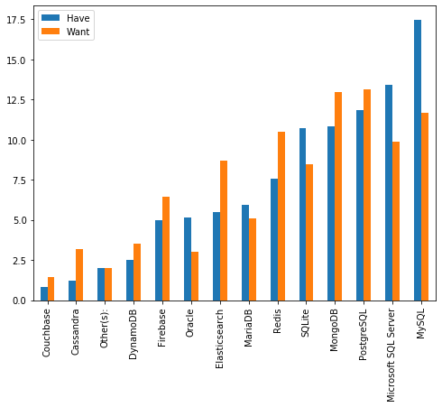

```python
# Generating test plot

comparison_relative_df.plot(y=["Have", "Want"], kind="bar")
```

```python
# Automating display for all categories

# Storing all relevant columns as list
relevant_columns = have_want_work.columns.tolist()

# Collecting all item interaction dataframes in list
df_item_interactions = [df_have_worked_languages,df_want_work_languages,df_have_worked_databases,df_want_work_databases,
                        df_have_worked_platforms,df_want_work_platforms,df_have_worked_webframes,df_want_work_webframes,
                        df_have_worked_misctechs,df_want_work_misctechs]
```

```python
# Collecting all ranked comparisons by category in list

ranked_data = []

for relevant_column,item_interaction in zip(relevant_columns,df_item_interactions):
    ranked_data.append(get_ranked_data(relevant_column,item_interaction))
```

```python
# Collecting all relative comparisons in list

relative_comparison_dfs = []

for element in range(0,9)[::2]:
    relative_comparison_dfs.append(generate_relative_comparison_df(ranked_data[element],ranked_data[element+1]))
```

```python
# Preparing Titles for display in graphs

graph_titles = ["Programming/Scripting/Markup Languages", "Database Environments",
                "Platforms", "Webframeworks","Miscellaneous Tech"]

graph_titles = ["Percentage Of Expected Usage of " + x + " in 2019/2020" for x in graph_titles]

graph_titles
```

```
['Percentage Of Expected Usage of Programming/Scripting/Markup Languages in 2019/2020',
 'Percentage Of Expected Usage of Database Environments in 2019/2020',
 'Percentage Of Expected Usage of Platforms in 2019/2020',
 'Percentage Of Expected Usage of Webframeworks in 2019/2020',
 'Percentage Of Expected Usage of Miscellaneous Tech in 2019/2020']
```

```
                            Have       Want
Erlang                 0.187643   0.572986
Clojure                0.257012   0.615025
WebAssembly            0.283461   2.635007
F#                     0.285458   1.137667
Elixir                 0.319892   1.035941
Dart                   0.505040   1.286104
Rust                   0.525502   2.318412
Scala                  0.691187   1.301674
Objective-C            0.779020   0.621772
R                      0.893802   1.457376
Assembly               1.045514   0.772285
Swift                  1.063978   1.950435
Kotlin                 1.070466   2.963021
VBA                    1.090428   0.356559
Other(s):              1.276075   1.408071
Ruby                   1.675816   1.754768
Go                     1.696776   4.536136
C                      3.050704   1.922408
C++                    3.510330   2.974958
PHP                    5.389260   2.995718
TypeScript             5.791496   7.805372
Java                   6.941312   4.733878
Bash/Shell/PowerShell  7.013674   5.262748
Python                 7.152410   8.613987
C#                     7.785707   6.947450
SQL                    11.645873  9.202024
HTML/CSS               13.419004  10.339172
JavaScript             14.653159  12.479045
```

```
                           Have       Want
Couchbase             0.841823   1.424937
Cassandra             1.205930   3.170461
Other(s):             2.005848   2.022311
DynamoDB              2.478908   3.514347
Firebase              4.974578   6.428525
Oracle                5.131954   3.030670
Elasticsearch         5.507236   8.705255
MariaDB               5.953290   5.106101
Redis                 7.591306   10.498309
SQLite                10.706237  8.487181
MongoDB               10.838471  12.972610
PostgreSQL            11.866538  13.108674
Microsoft SQL Server  13.430987  9.884160
MySQL                 17.466895  11.646459
```

```
                            Have       Want
IBM Cloud or Watson    0.615559   1.011165
Other(s):              0.779509   0.660972
Kubernetes             2.723811   6.619414
Arduino                2.997310   3.582689
iOS                    3.706767   4.568656
Heroku                 3.884132   3.052232
Google Cloud Platform  4.070439   5.677384
Raspberry Pi           4.471372   5.841496
WordPress              4.541424   2.122477
Microsoft Azure        4.864108   5.275502
MacOS                  6.344132   5.720673
Slack                  6.721963   5.176647
Android                7.707155   7.599566
AWS                    8.595468   9.473290
Docker                 9.918994   11.888455
Linux                  13.704755  12.348487
Windows                14.353104  9.380896
```

```
                         Have       Want
Drupal              1.292825   0.808365
Other(s):           2.700927   2.714847
Ruby on Rails       2.858220   3.550507
Laravel             3.986210   3.631344
Flask               4.889033   5.146241
Django              4.912734   6.282151
Spring              5.113122   4.997165
Vue.js              6.423185   12.478216
Express             9.983840   9.377034
React.js            13.000431  18.086380
ASP.NET             13.108166  10.693514
Angular/Angular.js  13.141564  12.299746
jQuery              18.589744  9.934491
```

```
                    Have       Want
CryEngine      0.263148   0.570403
Chef           1.134166   1.229536
Puppet         1.214426   1.278289
Torch/PyTorch  1.249951   3.074328
Unreal Engine  1.324948   3.041176
Flutter        1.631515   4.003549
Other(s):      1.751247   1.477198
Hadoop         1.967028   3.240086
Apache Spark   2.381485   3.392194
Xamarin        3.263029   3.854367
Cordova        3.991948   2.074903
TensorFlow     4.068260   9.101103
Ansible        4.298515   3.804639
Unity 3D       4.394563   5.553876
Pandas         5.040591   4.339941
React Native   5.618199   8.973371
.NET Core      12.453456  11.447069
.NET           17.862453  9.733909
Node.js        26.091075  19.810061
```

[figure not shown]

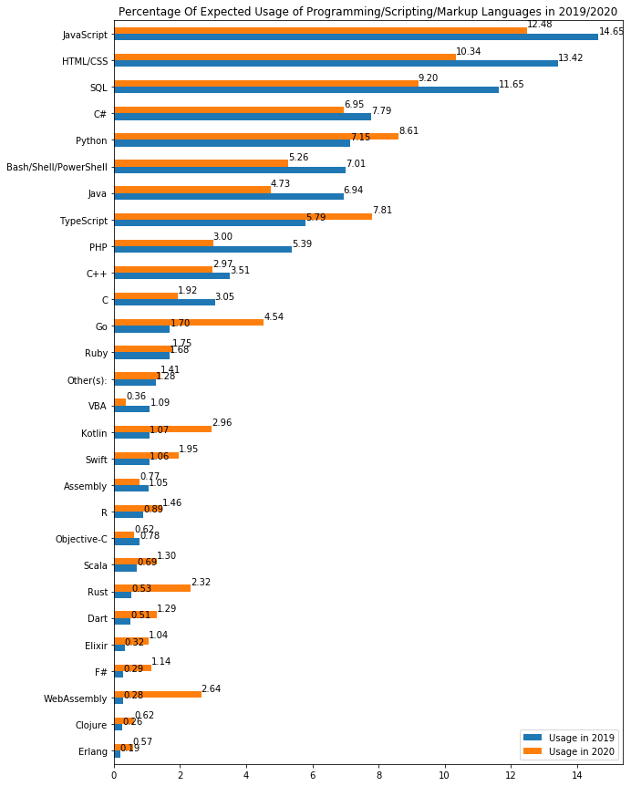

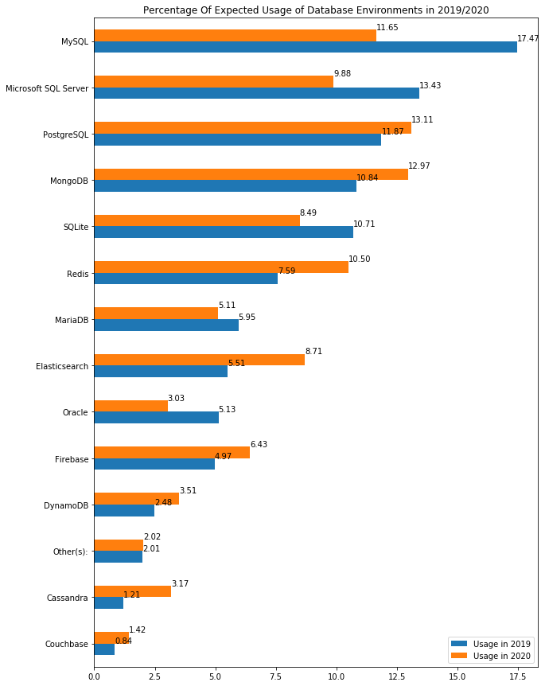

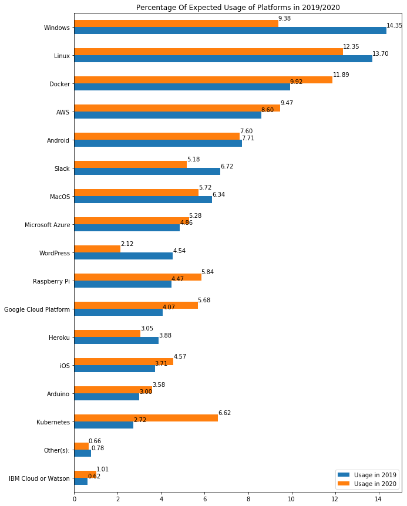

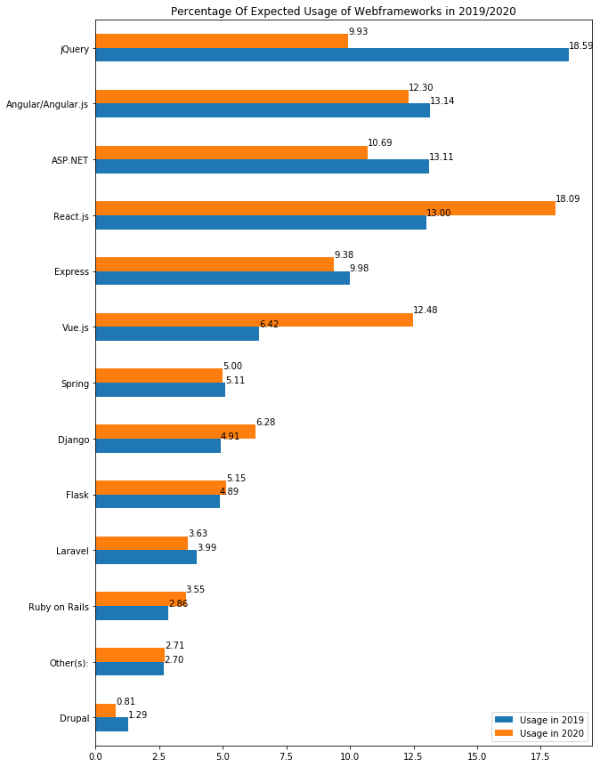

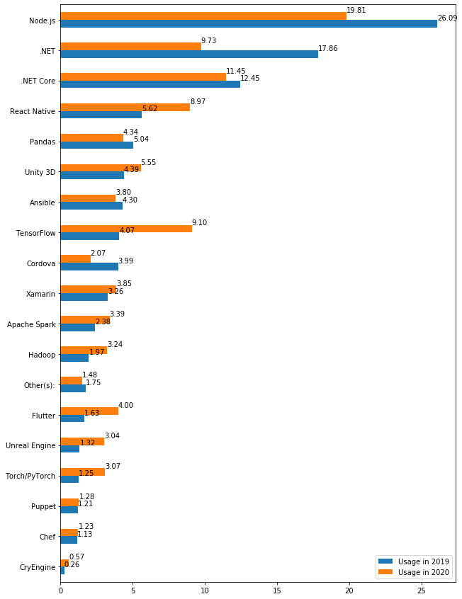

```python
# Plotting the graphs

%matplotlib inline

for graph_index, relative_comparison_df in enumerate(relative_comparison_dfs):
    print(relative_comparison_df)
    # Setting graph size
    plt.rcParams["figure.figsize"] = (10,15)

    # Inserting title
    plt.title(graph_titles[graph_index-1])

    # Plotting graph with legend and annotations
    ax = relative_comparison_df.plot(y=["Have", "Want"], kind="barh")
    ax.legend(["Usage in 2019","Usage in 2020"])

    # https://stackoverflow.com/questions/25447700/annotate-bars-with-values-on-pandas-bar-plots
    x_offset = 0
    y_offset = 0
    for p in ax.patches:
        b = p.get_bbox()
        val = "{:.2f}".format(b.x1 + b.x0)
        ax.annotate(val, ((b.x0 + b.x1), b.y1))
```